# Close-up shots and empathy affect enjoyment of movies

# EEG frontal asymmetry (approach motivation)

## Distribution of FEA

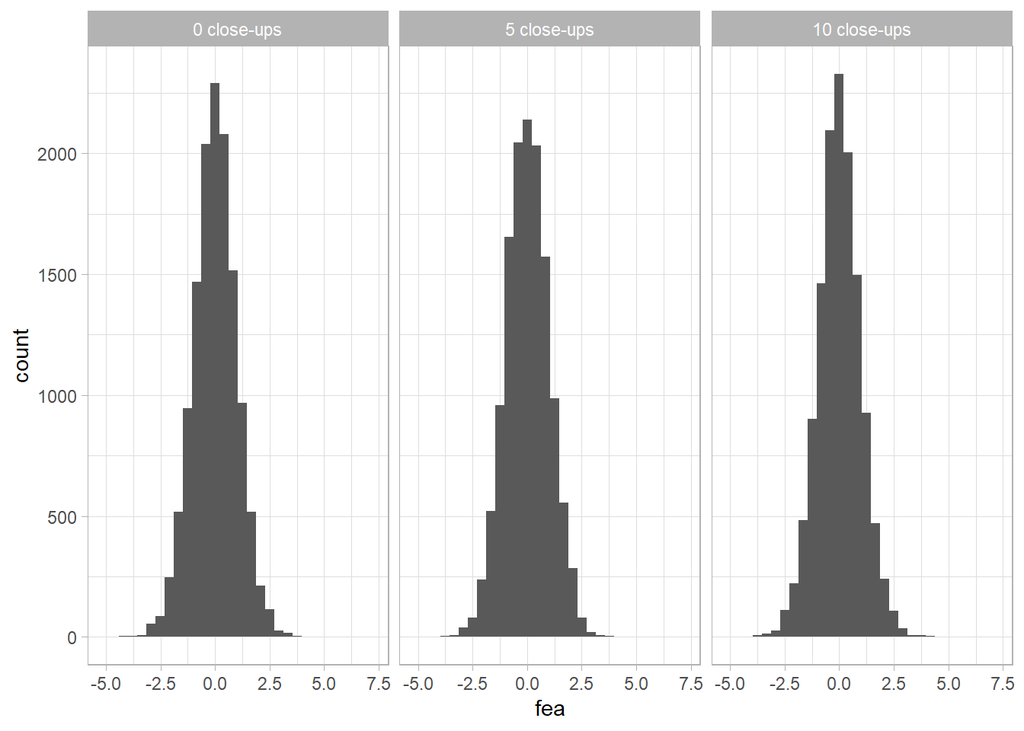

```r
fea %>%
        ggplot() +
        aes(x = fea) +
        geom_histogram() +
        facet_wrap(~stimulus)
```

## FEA according to sequence and stimuli

The effect of CU-s was investigated within each movie sequence, which did, or did not include a close-up

We used a mixed-effect model with a three level nested random structure, where the film sequence was crossed (everyone saw). Level 1 was the individual participants with Empathy as a random slope Level 2 was the sequence Level 3 was the stimuli in which the sequence was embedded

```r
fea %>%
        group_by(TestId, stimulus, sequence, cu) %>%
        summarise(fea_mean = mean(fea, na.rm = TRUE)) %>%
        ungroup() %>%
        left_join(psy, by = c("TestId", "stimulus")) %>%
        lmer(fea_mean ~ stimulus * sequence * cu + scale(Empathy) + (scale(Empathy)|TestId) + (1|stimulus/sequence),
             data = .) %>%
        summary()
```

```
## fixed-effect model matrix is rank deficient so dropping 3 columns / coefficients
```

```
## boundary (singular) fit: see ?isSingular
```

```
## Linear mixed model fit by REML. t-tests use Satterthwaite's method [
## lmerModLmerTest]
## Formula:
## fea_mean ~ stimulus * sequence * cu + scale(Empathy) + (scale(Empathy) |
##     TestId) + (1 | stimulus/sequence)
##    Data: .
##
## REML criterion at convergence: 1264.2
##
## Scaled residuals:
##      Min       1Q   Median       3Q      Max
## -3.11149 -0.70469  0.03347  0.65951  3.07063
##
## Random effects:
##  Groups            Name           Variance  Std.Dev.  Corr
##  TestId            (Intercept)    0.000e+00 0.000e+00
##                    scale(Empathy) 1.825e-10 1.351e-05  NaN
##  sequence:stimulus (Intercept)    1.284e-08 1.133e-04
##  stimulus          (Intercept)    2.532e-01 5.032e-01
##  Residual                         1.981e-01 4.451e-01
## Number of obs: 996, groups:
## TestId, 97; sequence:stimulus, 33; stimulus, 3
##
## Fixed effects:
##                                  Estimate Std. Error         df t value
## (Intercept)                    -1.366e-02  5.059e-01  9.860e+02  -0.027
## stimulus5 close-ups            -2.983e-02  7.165e-01  9.860e+02  -0.042
## stimulus10 close-ups            7.179e-02  7.480e-01  9.860e+02   0.096
## sequence                        6.558e-04  7.933e-03  9.844e+02   0.083
## cuClose-up                     -2.920e-02  2.093e-01  9.845e+02  -0.139
## scale(Empathy)                 -1.546e-02  1.464e-02  9.860e+02  -1.055
## stimulus5 close-ups:sequence    8.992e-03  1.270e-02  9.844e+02   0.708
## stimulus10 close-ups:sequence  -4.936e-03  2.011e-02  9.844e+02  -0.245
## stimulus5 close-ups:cuClose-up  1.851e-02  1.467e-01  9.848e+02   0.126
## sequence:cuClose-up            -1.015e-03  1.619e-02  9.844e+02  -0.063
##                                Pr(>|t|)
## (Intercept)                       0.978
## stimulus5 close-ups               0.967
## stimulus10 close-ups              0.924
## sequence                          0.934
## cuClose-up                        0.889
## scale(Empathy)                    0.291
## stimulus5 close-ups:sequence      0.479
## stimulus10 close-ups:sequence     0.806
## stimulus5 close-ups:cuClose-up    0.900
## sequence:cuClose-up               0.950
##
## Correlation of Fixed Effects:
##             (Intr) stm5c- st10c- sequnc cCls-p scl(E) st5c-: s10c-: s5c-:C
## stmls5cls-p -0.706
## stmls10cls- -0.676  0.489
## sequence    -0.092  0.065  0.062
## cuClose-up   0.000 -0.041 -0.291  0.000
## scl(Empthy) -0.004 -0.004  0.009  0.025  0.001
## stmls5cls-:  0.057 -0.102 -0.153 -0.625  0.407 -0.011
## stmls10cl-:  0.036 -0.064 -0.274 -0.394  0.790 -0.009  0.632
## stmls5c-:C-  0.000  0.018  0.262  0.000 -0.881 -0.002 -0.280 -0.610
## sqnc:cCls-p  0.000  0.048  0.238  0.000 -0.851  0.001 -0.478 -0.805  0.572
## fit warnings:
## fixed-effect model matrix is rank deficient so dropping 3 columns / coefficients
## convergence code: 0
## boundary (singular) fit: see ?isSingular
```

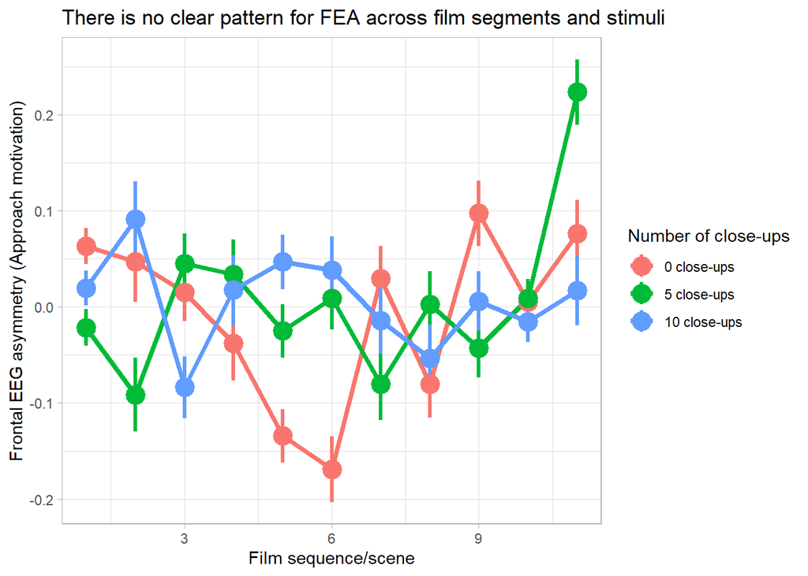

```r
fea %>%
        group_by(stimulus, sequence) %>%
        summarise(fea_mean = mean(fea),
                  fea_se = sd(fea)/sqrt(n())) %>%
        ungroup() %>%
        ggplot() +
        aes(x = sequence, y = fea_mean,
            ymin = fea_mean - fea_se, ymax = fea_mean + fea_se,
            color = stimulus) +
        geom_line(size = 1.5) +
        geom_pointrange(size = 1.2) +
        labs(title = "There is no clear pattern for FEA across film segments and stimuli",
             y = "Frontal EEG asymmetry (Approach motivation)",
             x = "Film sequence/scene",
             color = "Number of close-ups")
```